# Risk Factor Analysis

## Outcome Variable

**Outcome Variable:** ever_wasted

## Predictor Variables

**Intervention Variable:** cleanck

**Adjustment Set:**

- arm
- sex
- W_mage
- meducyrs
- feducyrs
- hhwealth_quart
- hfoodsec
- W_nrooms
- W_nhh
- W_nchldlt5
- W_parity
- impfloor
- delta_meducyrs
- delta_feducyrs
- delta_hhwealth_quart
- delta_hfoodsec
- delta_W_nrooms
- delta_W_nhh
- delta_W_nchldlt5
- delta_W_parity
- delta_impfloor

## Stratifying Variables

The analysis was stratified on these variable(s):

- agecat
- studyid
- country

## Data Summary

| agecat | studyid | country | cleanck | ever_wasted | n_cell | n |
| --- | --- | --- | --- | --- | --- | --- |
| 0-24 months (no birth wast) | ki0047075b-MAL-ED | PERU | 0 | 0 | 1 | 2 |
| 0-24 months (no birth wast) | ki0047075b-MAL-ED | PERU | 0 | 1 | 0 | 2 |
| 0-24 months (no birth wast) | ki0047075b-MAL-ED | PERU | 1 | 0 | 1 | 2 |
| 0-24 months (no birth wast) | ki0047075b-MAL-ED | PERU | 1 | 1 | 0 | 2 |
| 0-24 months (no birth wast) | ki0047075b-MAL-ED | SOUTH AFRICA | 0 | 0 | 1 | 3 |
| 0-24 months (no birth wast) | ki0047075b-MAL-ED | SOUTH AFRICA | 0 | 1 | 0 | 3 |
| 0-24 months (no birth wast) | ki0047075b-MAL-ED | SOUTH AFRICA | 1 | 0 | 2 | 3 |
| 0-24 months (no birth wast) | ki0047075b-MAL-ED | SOUTH AFRICA | 1 | 1 | 0 | 3 |
| 0-24 months (no birth wast) | ki1000108-CMC-V-BCS-2002 | INDIA | 0 | 0 | 98 | 368 |
| 0-24 months (no birth wast) | ki1000108-CMC-V-BCS-2002 | INDIA | 0 | 1 | 107 | 368 |
| 0-24 months (no birth wast) | ki1000108-CMC-V-BCS-2002 | INDIA | 1 | 0 | 104 | 368 |
| 0-24 months (no birth wast) | ki1000108-CMC-V-BCS-2002 | INDIA | 1 | 1 | 59 | 368 |
| 0-24 months (no birth wast) | ki1000108-IRC | INDIA | 0 | 0 | 84 | 399 |
| 0-24 months (no birth wast) | ki1000108-IRC | INDIA | 0 | 1 | 85 | 399 |
| 0-24 months (no birth wast) | ki1000108-IRC | INDIA | 1 | 0 | 107 | 399 |
| 0-24 months (no birth wast) | ki1000108-IRC | INDIA | 1 | 1 | 123 | 399 |
| 0-24 months (no birth wast) | ki1017093b-PROVIDE | BANGLADESH | 0 | 0 | 94 | 687 |
| 0-24 months (no birth wast) | ki1017093b-PROVIDE | BANGLADESH | 0 | 1 | 32 | 687 |
| 0-24 months (no birth wast) | ki1017093b-PROVIDE | BANGLADESH | 1 | 0 | 471 | 687 |
| 0-24 months (no birth wast) | ki1017093b-PROVIDE | BANGLADESH | 1 | 1 | 90 | 687 |
| 0-24 months (no birth wast) | ki1017093c-NIH-Crypto | BANGLADESH | 0 | 0 | 181 | 575 |
| 0-24 months (no birth wast) | ki1017093c-NIH-Crypto | BANGLADESH | 0 | 1 | 36 | 575 |
| 0-24 months (no birth wast) | ki1017093c-NIH-Crypto | BANGLADESH | 1 | 0 | 319 | 575 |
| 0-24 months (no birth wast) | ki1017093c-NIH-Crypto | BANGLADESH | 1 | 1 | 39 | 575 |
| 0-24 months (no birth wast) | ki1113344-GMS-Nepal | NEPAL | 0 | 0 | 470 | 1050 |
| 0-24 months (no birth wast) | ki1113344-GMS-Nepal | NEPAL | 0 | 1 | 562 | 1050 |
| 0-24 months (no birth wast) | ki1113344-GMS-Nepal | NEPAL | 1 | 0 | 12 | 1050 |
| 0-24 months (no birth wast) | ki1113344-GMS-Nepal | NEPAL | 1 | 1 | 6 | 1050 |
| 0-6 months (no birth wast) | ki0047075b-MAL-ED | PERU | 0 | 0 | 1 | 2 |
| 0-6 months (no birth wast) | ki0047075b-MAL-ED | PERU | 0 | 1 | 0 | 2 |
| 0-6 months (no birth wast) | ki0047075b-MAL-ED | PERU | 1 | 0 | 1 | 2 |
| 0-6 months (no birth wast) | ki0047075b-MAL-ED | PERU | 1 | 1 | 0 | 2 |
| 0-6 months (no birth wast) | ki0047075b-MAL-ED | SOUTH AFRICA | 0 | 0 | 1 | 3 |
| 0-6 months (no birth wast) | ki0047075b-MAL-ED | SOUTH AFRICA | 0 | 1 | 0 | 3 |
| 0-6 months (no birth wast) | ki0047075b-MAL-ED | SOUTH AFRICA | 1 | 0 | 2 | 3 |
| 0-6 months (no birth wast) | ki0047075b-MAL-ED | SOUTH AFRICA | 1 | 1 | 0 | 3 |
| 0-6 months (no birth wast) | ki1000108-CMC-V-BCS-2002 | INDIA | 0 | 0 | 125 | 350 |
| 0-6 months (no birth wast) | ki1000108-CMC-V-BCS-2002 | INDIA | 0 | 1 | 68 | 350 |
| 0-6 months (no birth wast) | ki1000108-CMC-V-BCS-2002 | INDIA | 1 | 0 | 117 | 350 |
| 0-6 months (no birth wast) | ki1000108-CMC-V-BCS-2002 | INDIA | 1 | 1 | 40 | 350 |
| 0-6 months (no birth wast) | ki1000108-IRC | INDIA | 0 | 0 | 115 | 381 |
| 0-6 months (no birth wast) | ki1000108-IRC | INDIA | 0 | 1 | 44 | 381 |
| 0-6 months (no birth wast) | ki1000108-IRC | INDIA | 1 | 0 | 136 | 381 |
| 0-6 months (no birth wast) | ki1000108-IRC | INDIA | 1 | 1 | 86 | 381 |
| 0-6 months (no birth wast) | ki1017093b-PROVIDE | BANGLADESH | 0 | 0 | 116 | 683 |
| 0-6 months (no birth wast) | ki1017093b-PROVIDE | BANGLADESH | 0 | 1 | 10 | 683 |
| 0-6 months (no birth wast) | ki1017093b-PROVIDE | BANGLADESH | 1 | 0 | 531 | 683 |
| 0-6 months (no birth wast) | ki1017093b-PROVIDE | BANGLADESH | 1 | 1 | 26 | 683 |
| 0-6 months (no birth wast) | ki1017093c-NIH-Crypto | BANGLADESH | 0 | 0 | 208 | 572 |
| 0-6 months (no birth wast) | ki1017093c-NIH-Crypto | BANGLADESH | 0 | 1 | 9 | 572 |
| 0-6 months (no birth wast) | ki1017093c-NIH-Crypto | BANGLADESH | 1 | 0 | 351 | 572 |
| 0-6 months (no birth wast) | ki1017093c-NIH-Crypto | BANGLADESH | 1 | 1 | 4 | 572 |
| 0-6 months (no birth wast) | ki1113344-GMS-Nepal | NEPAL | 0 | 0 | 850 | 1012 |
| 0-6 months (no birth wast) | ki1113344-GMS-Nepal | NEPAL | 0 | 1 | 146 | 1012 |
| 0-6 months (no birth wast) | ki1113344-GMS-Nepal | NEPAL | 1 | 0 | 12 | 1012 |
| 0-6 months (no birth wast) | ki1113344-GMS-Nepal | NEPAL | 1 | 1 | 4 | 1012 |
| 6-24 months | ki0047075b-MAL-ED | SOUTH AFRICA | 0 | 0 | 0 | 1 |
| 6-24 months | ki0047075b-MAL-ED | SOUTH AFRICA | 0 | 1 | 0 | 1 |
| 6-24 months | ki0047075b-MAL-ED | SOUTH AFRICA | 1 | 0 | 1 | 1 |
| 6-24 months | ki0047075b-MAL-ED | SOUTH AFRICA | 1 | 1 | 0 | 1 |
| 6-24 months | ki1000108-CMC-V-BCS-2002 | INDIA | 0 | 0 | 146 | 373 |
| 6-24 months | ki1000108-CMC-V-BCS-2002 | INDIA | 0 | 1 | 64 | 373 |
| 6-24 months | ki1000108-CMC-V-BCS-2002 | INDIA | 1 | 0 | 128 | 373 |
| 6-24 months | ki1000108-CMC-V-BCS-2002 | INDIA | 1 | 1 | 35 | 373 |
| 6-24 months | ki1000108-IRC | INDIA | 0 | 0 | 110 | 400 |
| 6-24 months | ki1000108-IRC | INDIA | 0 | 1 | 59 | 400 |
| 6-24 months | ki1000108-IRC | INDIA | 1 | 0 | 166 | 400 |
| 6-24 months | ki1000108-IRC | INDIA | 1 | 1 | 65 | 400 |
| 6-24 months | ki1017093b-PROVIDE | BANGLADESH | 0 | 0 | 79 | 615 |
| 6-24 months | ki1017093b-PROVIDE | BANGLADESH | 0 | 1 | 28 | 615 |
| 6-24 months | ki1017093b-PROVIDE | BANGLADESH | 1 | 0 | 437 | 615 |
| 6-24 months | ki1017093b-PROVIDE | BANGLADESH | 1 | 1 | 71 | 615 |
| 6-24 months | ki1017093c-NIH-Crypto | BANGLADESH | 0 | 0 | 186 | 559 |
| 6-24 months | ki1017093c-NIH-Crypto | BANGLADESH | 0 | 1 | 30 | 559 |
| 6-24 months | ki1017093c-NIH-Crypto | BANGLADESH | 1 | 0 | 306 | 559 |
| 6-24 months | ki1017093c-NIH-Crypto | BANGLADESH | 1 | 1 | 37 | 559 |
| 6-24 months | ki1113344-GMS-Nepal | NEPAL | 0 | 0 | 538 | 1058 |
| 6-24 months | ki1113344-GMS-Nepal | NEPAL | 0 | 1 | 504 | 1058 |
| 6-24 months | ki1113344-GMS-Nepal | NEPAL | 1 | 0 | 12 | 1058 |
| 6-24 months | ki1113344-GMS-Nepal | NEPAL | 1 | 1 | 4 | 1058 |

The following strata were considered:

- agecat: 0-24 months (no birth wast), studyid: ki0047075b-MAL-ED, country: PERU
- agecat: 0-24 months (no birth wast), studyid: ki0047075b-MAL-ED, country: SOUTH AFRICA
- agecat: 0-24 months (no birth wast), studyid: ki1000108-CMC-V-BCS-2002, country: INDIA
- agecat: 0-24 months (no birth wast), studyid: ki1000108-IRC, country: INDIA
- agecat: 0-24 months (no birth wast), studyid: ki1017093b-PROVIDE, country: BANGLADESH
- agecat: 0-24 months (no birth wast), studyid: ki1017093c-NIH-Crypto, country: BANGLADESH
- agecat: 0-24 months (no birth wast), studyid: ki1113344-GMS-Nepal, country: NEPAL
- agecat: 0-6 months (no birth wast), studyid: ki0047075b-MAL-ED, country: PERU
- agecat: 0-6 months (no birth wast), studyid: ki0047075b-MAL-ED, country: SOUTH AFRICA
- agecat: 0-6 months (no birth wast), studyid: ki1000108-CMC-V-BCS-2002, country: INDIA
- agecat: 0-6 months (no birth wast), studyid: ki1000108-IRC, country: INDIA
- agecat: 0-6 months (no birth wast), studyid: ki1017093b-PROVIDE, country: BANGLADESH
- agecat: 0-6 months (no birth wast), studyid: ki1017093c-NIH-Crypto, country: BANGLADESH
- agecat: 0-6 months (no birth wast), studyid: ki1113344-GMS-Nepal, country: NEPAL
- agecat: 6-24 months, studyid: ki0047075b-MAL-ED, country: SOUTH AFRICA
- agecat: 6-24 months, studyid: ki1000108-CMC-V-BCS-2002, country: INDIA
- agecat: 6-24 months, studyid: ki1000108-IRC, country: INDIA
- agecat: 6-24 months, studyid: ki1017093b-PROVIDE, country: BANGLADESH
- agecat: 6-24 months, studyid: ki1017093c-NIH-Crypto, country: BANGLADESH
- agecat: 6-24 months, studyid: ki1113344-GMS-Nepal, country: NEPAL

### Dropped Strata

Some strata were dropped due to rare outcomes:

- agecat: 0-24 months (no birth wast), studyid: ki0047075b-MAL-ED, country: PERU
- agecat: 0-24 months (no birth wast), studyid: ki0047075b-MAL-ED, country: SOUTH AFRICA
- agecat: 0-6 months (no birth wast), studyid: ki0047075b-MAL-ED, country: PERU
- agecat: 0-6 months (no birth wast), studyid: ki0047075b-MAL-ED, country: SOUTH AFRICA
- agecat: 0-6 months (no birth wast), studyid: ki1017093c-NIH-Crypto, country: BANGLADESH
- agecat: 0-6 months (no birth wast), studyid: ki1113344-GMS-Nepal, country: NEPAL
- agecat: 6-24 months, studyid: ki0047075b-MAL-ED, country: SOUTH AFRICA
- agecat: 6-24 months, studyid: ki1113344-GMS-Nepal, country: NEPAL

## Methods Detail

We’re interested in the causal parameters $E[Y_a]$ for all values of $a \in \mathcal{A}$. These parameters represent the mean outcome if, possibly contrary to fact, we intervened to set all units to have $A=a$. Under the randomization and positivity assumptions, these are identified by the statistical parameters $\psi_a=E_W[E_{Y|A,W}(Y|A=a,W)]$. In addition, we’re interested in the mean of $Y$, $E[Y]$ under no intervention (the observed mean). We will estimate these parameters by using SuperLearner to fit the relevant likelihood factors – $E_{Y|A,W}(Y|A=a,W)$ and $p(A=a|W)$, and then updating our likelihood fit using a joint TMLE.

For unadjusted analyses ($W=\{\}$), initial likelihoods were estimated using Lrnr_glm to estimate the simple $E(Y|A)$ and Lrnr_mean to estimate $p(A)$. For adjusted analyses, a small library containing Lrnr_glmnet, Lrnr_xgboost, and Lrnr_mean was used.

Having estimated these parameters, we will then use the delta method to estimate relative risks and attributable risks relative to a prespecified baseline level of $A$.

# Results Detail

## Results Plots

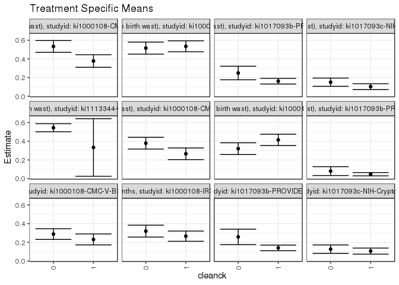

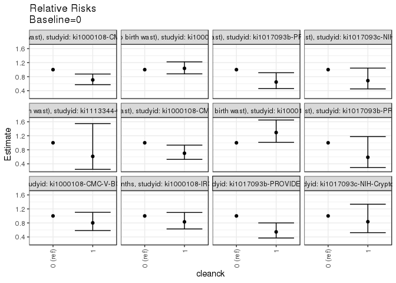

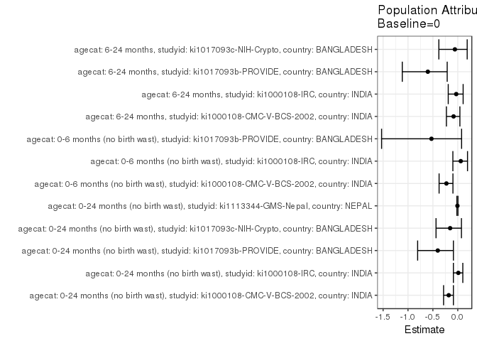

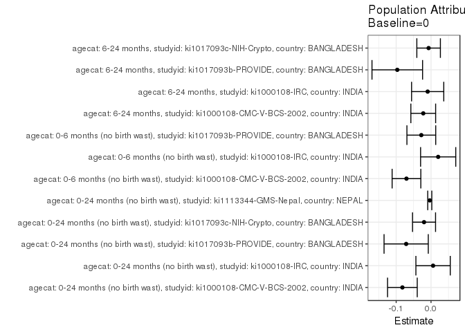

## Results Table

### Parameter: TSM

| agecat | studyid | country | intervention_level | baseline_level | estimate | ci_lower | ci_upper |
| --- | --- | --- | --- | --- | --- | --- | --- |
| 0-24 months (no birth wast) | ki1000108-CMC-V-BCS-2002 | INDIA | 0 | NA | 0.5332239 | 0.4701452 | 0.5963026 |
| 0-24 months (no birth wast) | ki1000108-CMC-V-BCS-2002 | INDIA | 1 | NA | 0.3770861 | 0.3100083 | 0.4441639 |
| 0-24 months (no birth wast) | ki1000108-IRC | INDIA | 0 | NA | 0.5154103 | 0.4509727 | 0.5798479 |
| 0-24 months (no birth wast) | ki1000108-IRC | INDIA | 1 | NA | 0.5344291 | 0.4757277 | 0.5931305 |
| 0-24 months (no birth wast) | ki1017093b-PROVIDE | BANGLADESH | 0 | NA | 0.2488909 | 0.1763316 | 0.3214502 |
| 0-24 months (no birth wast) | ki1017093b-PROVIDE | BANGLADESH | 1 | NA | 0.1610231 | 0.1308093 | 0.1912369 |
| 0-24 months (no birth wast) | ki1017093c-NIH-Crypto | BANGLADESH | 0 | NA | 0.1504513 | 0.1062068 | 0.1946959 |
| 0-24 months (no birth wast) | ki1017093c-NIH-Crypto | BANGLADESH | 1 | NA | 0.1032197 | 0.0723044 | 0.1341350 |
| 0-24 months (no birth wast) | ki1113344-GMS-Nepal | NEPAL | 0 | NA | 0.5445736 | 0.5015631 | 0.5875842 |
| 0-24 months (no birth wast) | ki1113344-GMS-Nepal | NEPAL | 1 | NA | 0.3333333 | 0.0250610 | 0.6416057 |
| 0-6 months (no birth wast) | ki1000108-CMC-V-BCS-2002 | INDIA | 0 | NA | 0.3790149 | 0.3159866 | 0.4420432 |
| 0-6 months (no birth wast) | ki1000108-CMC-V-BCS-2002 | INDIA | 1 | NA | 0.2657222 | 0.2037113 | 0.3277330 |
| 0-6 months (no birth wast) | ki1000108-IRC | INDIA | 0 | NA | 0.3206889 | 0.2577799 | 0.3835980 |
| 0-6 months (no birth wast) | ki1000108-IRC | INDIA | 1 | NA | 0.4146026 | 0.3540277 | 0.4751775 |
| 0-6 months (no birth wast) | ki1017093b-PROVIDE | BANGLADESH | 0 | NA | 0.0805528 | 0.0331628 | 0.1279428 |
| 0-6 months (no birth wast) | ki1017093b-PROVIDE | BANGLADESH | 1 | NA | 0.0472600 | 0.0296504 | 0.0648697 |
| 6-24 months | ki1000108-CMC-V-BCS-2002 | INDIA | 0 | NA | 0.2877108 | 0.2305500 | 0.3448715 |
| 6-24 months | ki1000108-CMC-V-BCS-2002 | INDIA | 1 | NA | 0.2307153 | 0.1721137 | 0.2893169 |
| 6-24 months | ki1000108-IRC | INDIA | 0 | NA | 0.3196106 | 0.2559340 | 0.3832872 |
| 6-24 months | ki1000108-IRC | INDIA | 1 | NA | 0.2655463 | 0.2109543 | 0.3201384 |
| 6-24 months | ki1017093b-PROVIDE | BANGLADESH | 0 | NA | 0.2577727 | 0.1751585 | 0.3403868 |
| 6-24 months | ki1017093b-PROVIDE | BANGLADESH | 1 | NA | 0.1402759 | 0.1101279 | 0.1704240 |
| 6-24 months | ki1017093c-NIH-Crypto | BANGLADESH | 0 | NA | 0.1267729 | 0.0818538 | 0.1716920 |
| 6-24 months | ki1017093c-NIH-Crypto | BANGLADESH | 1 | NA | 0.1057865 | 0.0731547 | 0.1384183 |

### Parameter: E(Y)

| agecat | studyid | country | intervention_level | baseline_level | estimate | ci_lower | ci_upper |
| --- | --- | --- | --- | --- | --- | --- | --- |
| 0-24 months (no birth wast) | ki1000108-CMC-V-BCS-2002 | INDIA | NA | NA | 0.4510870 | 0.4001777 | 0.5019962 |
| 0-24 months (no birth wast) | ki1000108-IRC | INDIA | NA | NA | 0.5213033 | 0.4722258 | 0.5703807 |
| 0-24 months (no birth wast) | ki1017093b-PROVIDE | BANGLADESH | NA | NA | 0.1775837 | 0.1489858 | 0.2061816 |
| 0-24 months (no birth wast) | ki1017093c-NIH-Crypto | BANGLADESH | NA | NA | 0.1304348 | 0.1028836 | 0.1579859 |
| 0-24 months (no birth wast) | ki1113344-GMS-Nepal | NEPAL | NA | NA | 0.5409524 | 0.4982855 | 0.5836193 |
| 0-6 months (no birth wast) | ki1000108-CMC-V-BCS-2002 | INDIA | NA | NA | 0.3085714 | 0.2601110 | 0.3570318 |
| 0-6 months (no birth wast) | ki1000108-IRC | INDIA | NA | NA | 0.3412073 | 0.2935379 | 0.3888768 |
| 0-6 months (no birth wast) | ki1017093b-PROVIDE | BANGLADESH | NA | NA | 0.0527086 | 0.0359384 | 0.0694789 |
| 6-24 months | ki1000108-CMC-V-BCS-2002 | INDIA | NA | NA | 0.2654155 | 0.2205451 | 0.3102860 |
| 6-24 months | ki1000108-IRC | INDIA | NA | NA | 0.3100000 | 0.2646197 | 0.3553803 |
| 6-24 months | ki1017093b-PROVIDE | BANGLADESH | NA | NA | 0.1609756 | 0.1319065 | 0.1900447 |
| 6-24 months | ki1017093c-NIH-Crypto | BANGLADESH | NA | NA | 0.1198569 | 0.0929081 | 0.1468057 |

### Parameter: RR

| agecat | studyid | country | intervention_level | baseline_level | estimate | ci_lower | ci_upper |
| --- | --- | --- | --- | --- | --- | --- | --- |
| 0-24 months (no birth wast) | ki1000108-CMC-V-BCS-2002 | INDIA | 0 | 0 | 1.0000000 | 1.0000000 | 1.0000000 |
| 0-24 months (no birth wast) | ki1000108-CMC-V-BCS-2002 | INDIA | 1 | 0 | 0.7071815 | 0.5715164 | 0.8750505 |
| 0-24 months (no birth wast) | ki1000108-IRC | INDIA | 0 | 0 | 1.0000000 | 1.0000000 | 1.0000000 |
| 0-24 months (no birth wast) | ki1000108-IRC | INDIA | 1 | 0 | 1.0369003 | 0.8793479 | 1.2226813 |
| 0-24 months (no birth wast) | ki1017093b-PROVIDE | BANGLADESH | 0 | 0 | 1.0000000 | 1.0000000 | 1.0000000 |
| 0-24 months (no birth wast) | ki1017093b-PROVIDE | BANGLADESH | 1 | 0 | 0.6469625 | 0.4588029 | 0.9122882 |
| 0-24 months (no birth wast) | ki1017093c-NIH-Crypto | BANGLADESH | 0 | 0 | 1.0000000 | 1.0000000 | 1.0000000 |
| 0-24 months (no birth wast) | ki1017093c-NIH-Crypto | BANGLADESH | 1 | 0 | 0.6860672 | 0.4507811 | 1.0441613 |
| 0-24 months (no birth wast) | ki1113344-GMS-Nepal | NEPAL | 0 | 0 | 1.0000000 | 1.0000000 | 1.0000000 |
| 0-24 months (no birth wast) | ki1113344-GMS-Nepal | NEPAL | 1 | 0 | 0.6120996 | 0.2419453 | 1.5485566 |
| 0-6 months (no birth wast) | ki1000108-CMC-V-BCS-2002 | INDIA | 0 | 0 | 1.0000000 | 1.0000000 | 1.0000000 |
| 0-6 months (no birth wast) | ki1000108-CMC-V-BCS-2002 | INDIA | 1 | 0 | 0.7010863 | 0.5265530 | 0.9334711 |
| 0-6 months (no birth wast) | ki1000108-IRC | INDIA | 0 | 0 | 1.0000000 | 1.0000000 | 1.0000000 |
| 0-6 months (no birth wast) | ki1000108-IRC | INDIA | 1 | 0 | 1.2928500 | 1.0127407 | 1.6504333 |
| 0-6 months (no birth wast) | ki1017093b-PROVIDE | BANGLADESH | 0 | 0 | 1.0000000 | 1.0000000 | 1.0000000 |
| 0-6 months (no birth wast) | ki1017093b-PROVIDE | BANGLADESH | 1 | 0 | 0.5866960 | 0.2921716 | 1.1781167 |
| 6-24 months | ki1000108-CMC-V-BCS-2002 | INDIA | 0 | 0 | 1.0000000 | 1.0000000 | 1.0000000 |
| 6-24 months | ki1000108-CMC-V-BCS-2002 | INDIA | 1 | 0 | 0.8019000 | 0.5829165 | 1.1031488 |
| 6-24 months | ki1000108-IRC | INDIA | 0 | 0 | 1.0000000 | 1.0000000 | 1.0000000 |
| 6-24 months | ki1000108-IRC | INDIA | 1 | 0 | 0.8308433 | 0.6280463 | 1.0991238 |
| 6-24 months | ki1017093b-PROVIDE | BANGLADESH | 0 | 0 | 1.0000000 | 1.0000000 | 1.0000000 |
| 6-24 months | ki1017093b-PROVIDE | BANGLADESH | 1 | 0 | 0.5441847 | 0.3701163 | 0.8001187 |
| 6-24 months | ki1017093c-NIH-Crypto | BANGLADESH | 0 | 0 | 1.0000000 | 1.0000000 | 1.0000000 |
| 6-24 months | ki1017093c-NIH-Crypto | BANGLADESH | 1 | 0 | 0.8344569 | 0.5220552 | 1.3338020 |

### Parameter: PAR

| agecat | studyid | country | intervention_level | baseline_level | estimate | ci_lower | ci_upper |
| --- | --- | --- | --- | --- | --- | --- | --- |
| 0-24 months (no birth wast) | ki1000108-CMC-V-BCS-2002 | INDIA | 0 | NA | -0.0821370 | -0.1247378 | -0.0395361 |
| 0-24 months (no birth wast) | ki1000108-IRC | INDIA | 0 | NA | 0.0058929 | -0.0433949 | 0.0551807 |
| 0-24 months (no birth wast) | ki1017093b-PROVIDE | BANGLADESH | 0 | NA | -0.0713072 | -0.1347450 | -0.0078695 |
| 0-24 months (no birth wast) | ki1017093c-NIH-Crypto | BANGLADESH | 0 | NA | -0.0200165 | -0.0530311 | 0.0129981 |
| 0-24 months (no birth wast) | ki1113344-GMS-Nepal | NEPAL | 0 | NA | -0.0036213 | -0.0094508 | 0.0022082 |
| 0-6 months (no birth wast) | ki1000108-CMC-V-BCS-2002 | INDIA | 0 | NA | -0.0704435 | -0.1116124 | -0.0292746 |
| 0-6 months (no birth wast) | ki1000108-IRC | INDIA | 0 | NA | 0.0205184 | -0.0299275 | 0.0709644 |
| 0-6 months (no birth wast) | ki1017093b-PROVIDE | BANGLADESH | 0 | NA | -0.0278442 | -0.0691652 | 0.0134769 |
| 6-24 months | ki1000108-CMC-V-BCS-2002 | INDIA | 0 | NA | -0.0222952 | -0.0578511 | 0.0132607 |
| 6-24 months | ki1000108-IRC | INDIA | 0 | NA | -0.0096106 | -0.0558016 | 0.0365804 |
| 6-24 months | ki1017093b-PROVIDE | BANGLADESH | 0 | NA | -0.0967971 | -0.1693649 | -0.0242292 |
| 6-24 months | ki1017093c-NIH-Crypto | BANGLADESH | 0 | NA | -0.0069160 | -0.0407120 | 0.0268800 |

### Parameter: PAF

| agecat | studyid | country | intervention_level | baseline_level | estimate | ci_lower | ci_upper |
| --- | --- | --- | --- | --- | --- | --- | --- |
| 0-24 months (no birth wast) | ki1000108-CMC-V-BCS-2002 | INDIA | 0 | NA | -0.1820868 | -0.2849270 | -0.0874775 |
| 0-24 months (no birth wast) | ki1000108-IRC | INDIA | 0 | NA | 0.0113043 | -0.0877518 | 0.1013398 |
| 0-24 months (no birth wast) | ki1017093b-PROVIDE | BANGLADESH | 0 | NA | -0.4015414 | -0.8062500 | -0.0875119 |
| 0-24 months (no birth wast) | ki1017093c-NIH-Crypto | BANGLADESH | 0 | NA | -0.1534601 | -0.4366668 | 0.0739188 |
| 0-24 months (no birth wast) | ki1113344-GMS-Nepal | NEPAL | 0 | NA | -0.0066942 | -0.0175464 | 0.0040422 |
| 0-6 months (no birth wast) | ki1000108-CMC-V-BCS-2002 | INDIA | 0 | NA | -0.2282890 | -0.3751941 | -0.0970770 |
| 0-6 months (no birth wast) | ki1000108-IRC | INDIA | 0 | NA | 0.0601348 | -0.0984902 | 0.1958540 |
| 0-6 months (no birth wast) | ki1017093b-PROVIDE | BANGLADESH | 0 | NA | -0.5282656 | -1.5304870 | 0.0770173 |
| 6-24 months | ki1000108-CMC-V-BCS-2002 | INDIA | 0 | NA | -0.0840011 | -0.2274945 | 0.0427180 |
| 6-24 months | ki1000108-IRC | INDIA | 0 | NA | -0.0310019 | -0.1915628 | 0.1079237 |
| 6-24 months | ki1017093b-PROVIDE | BANGLADESH | 0 | NA | -0.6013151 | -1.1149165 | -0.2124403 |
| 6-24 months | ki1017093c-NIH-Crypto | BANGLADESH | 0 | NA | -0.0577023 | -0.3798319 | 0.1892243 |